# Map Of Memories

## Project nember 4

### Team members:

- Imri Elkouby
- Yuval Kirshner
- Noa Manor

##### link to data: https://www.kaggle.com/datasets/nada144/israeli-palestinian-conflict

כל חברות הקבוצה תרמו במידה שווה לכל שלבי העבודה.  
שלבים אלו כללו איסוף הנתונים, ניתוחם, ביצוע החישובים, בניית הגרפים וכתיבת הדוח.  
למרות הקושי שחלק מהצוות היה בשירות מילואים, תהליך העבודה בוצע בשיתוף פעולה מלא.  
כל ההחלטות התקבלו במשותף.  
המידע נאסף ונבדק על ידי בצלם.

[figure not shown]

```python
import numpy as np
import pandas as pd
import matplotlib.pyplot as plt
import seaborn as sns
import random
import plotly.graph_objects as go
from sklearn.preprocessing import OneHotEncoder
import warnings
warnings.filterwarnings('ignore')
url = "https://raw.githubusercontent.com/ImriElkouby/Project/main/Israeli%20civilians%20killed%20by%20Palestinians.csv"
terror_df = pd.read_csv(url, encoding="ISO-8859-8")
```

### Data Cleaning and Preprocessing:

```python
terror_df.rename(columns={'Took part in the hostilities': 'Background in terrorism'}, inplace=True)
terror_df['Background in terrorism'] = terror_df['Background in terrorism'].fillna('No')
terror_df['Background in terrorism'] = terror_df['Background in terrorism'].str.replace('Israelis','Yes',regex = False)
```

```python
terror_df['date_event']=pd.to_datetime(terror_df['Date of event'],format='%m/%d/%Y')
terror_df['date_death']=pd.to_datetime(terror_df['Date of death'],format='%m/%d/%Y')
terror_df['weekday_event'] = pd.DatetimeIndex(terror_df['date_event']).strftime('%A')
terror_df['month_event'] = pd.DatetimeIndex(terror_df['date_event']).month
```

```python
terror_df['event to death time'] = (terror_df['date_death'] - terror_df['date_event']).dt.days
```

```python
terror_df[terror_df['date_event']=='2001-05-09']#שני הנערים נרצחו באותו פיגוע , נתקן את בעיית המינוס 1 בימים שזה לא הגיוני
terror_df.loc[834,'event to death time']=0
```

```python
# טבלת תאריכי רמדאן 2000-2023
ramadan_dates = pd.DataFrame({'year': list(range(2000, 2024)),'ramadan_start':
        ['2000-11-27', '2001-11-16', '2002-11-06', '2003-10-27', '2004-10-16',
        '2005-10-05', '2006-09-24', '2007-09-13', '2008-09-01', '2009-08-22',
        '2010-08-11', '2011-08-01', '2012-07-20', '2013-07-09', '2014-06-29',
        '2015-06-18', '2016-06-06', '2017-05-27', '2018-05-16', '2019-05-06',
        '2020-04-24', '2021-04-13', '2022-04-02', '2023-03-23'],

'ramadan_end': ['2000-12-26', '2001-12-15', '2002-12-05', '2003-11-25', '2004-11-14',
        '2005-11-03', '2006-10-23', '2007-10-12', '2008-09-30', '2009-09-20',
        '2010-09-09', '2011-08-29', '2012-08-18', '2013-08-07', '2014-07-27',
        '2015-07-16', '2016-07-05', '2017-06-24', '2018-06-14', '2019-06-04',
        '2020-05-23', '2021-05-12', '2022-05-01', '2023-04-20']})


# הפיכת העמודות לתאריכים
ramadan_dates['ramadan_start'] = pd.to_datetime(ramadan_dates['ramadan_start'])
ramadan_dates['ramadan_end'] = pd.to_datetime(ramadan_dates['ramadan_end'])

# פונקציה שבודקת אם כל פיגוע נפל ברמדאן
def is_in_ramadan(row):
    event_date = row['date_event']
    event_year = event_date.year
    ramadan_row = ramadan_dates[ramadan_dates['year'] == event_year]
    if not ramadan_row.empty:
        start = ramadan_row['ramadan_start'].values[0]
        end = ramadan_row['ramadan_end'].values[0]
        return start <= event_date <= end
    else:
        return False  # אם השנה לא בטווח שלנו

terror_df['is_in_ramadan'] = terror_df.apply(is_in_ramadan, axis=1)
```

```python
terror_df['Type of injury'] = terror_df['Type of injury'].str.replace('physically assaulted', 'physical assault', regex = False)
 #היה כפילות בשם של אחד הסוגי פגיעה, יצרנו עמודה חדשה שתאחד בין הכפילות
terror_df['Event location'] = terror_df['Event location'].replace({'Tel Aviv': 'Tel Aviv-Yafo','Tel Aviv-Yafo-Yafo':'Tel Aviv-Yafo','Old City (Jerusalem)':'Jerusalem','East Jerusalem':'Jerusalem','West Jerusalem':'Jerusalem'})
```

```python
terror_df['injury_groups'] = terror_df['Type of injury'].replace({'beating': 'physical assault','physical assault': 'physical assault','Strangulation': 'physical assault'})
Type_of_injury_ordered=['stones throwing','physical assault','stabbing','being bludgeoned with an axe','hit by a vehicle','gunfire','explosion']
terror_df['Type_of_injury_coded'] = pd.Categorical(terror_df['injury_groups'], categories=Type_of_injury_ordered,ordered=True).codes
terror_df['Ammunition']=terror_df['Ammunition'].replace({'missile':'rocket','grad rocket':'rocket','Qassam rocket':'rocket','mortar fire':'rocket'})
```

```python
grouped_incidents_full = terror_df.groupby(['date_event', 'Event location'])\
.agg({'Event location - Region': 'first','Background in terrorism':'first','Citizenship':'first','Ammunition': 'first','Type of injury': lambda x: x.dropna().unique()[0] if len(x.dropna().unique()) > 0 else None,'injury_groups': lambda x: x.dropna().unique()[0] if len(x.dropna().unique()) > 0 else None,'Name':'count','is_in_ramadan':'first'}).reset_index().rename(columns={'Name': 'Victim Count'})
#דאטה שכל שורה בה היא פיגוע
```

### Data Describe:

הדאטה מכילה מידע על קורבנות פיגועים בישראל.  
כל שורה בדאטה היא קורבן אחר.  
הפיגועים שתועדו בדאטה התבצעו רק ע"י מחבלים פלסטינאים כנגד אוכלוסיה אזרחית ישראלית בין השנים 2000–2023.  
במהלך העבודה יצרנו דאטה חדשה ע"י מזהה של מיקום ותאריך, בדאטה חדשה שכל שורה בה היא פיגוע.

```python
terror_df.head(2)
```

|  | Name | Date of event | Age | Citizenship | Event location | Event location - District | Event location - Region | Date of death | Gender | Background in terrorism | ... | Killed By | Notes | date_event | date_death | weekday_event | month_event | event to death time | is_in_ramadan | injury_groups | Type_of_injury_coded |
| --- | --- | --- | --- | --- | --- | --- | --- | --- | --- | --- | --- | --- | --- | --- | --- | --- | --- | --- | --- | --- | --- |
| 0 | Batsheva Nagari | 8/21/2023 | 40 | Israeli | Beit Hagai | Hebron | West Bank | 8/21/2023 | F | No | ... | Palestinian civilians | Fatally shot by Palestinians in a drive by sho... | 2023-08-21 | 2023-08-21 | Monday | 8 | 0 | False | gunfire | 5 |
| 1 | Aviad Nir | 8/19/2023 | 28 | Israeli | Huwarah | Nablus | West Bank | 8/19/2023 | M | No | ... | Palestinian civilians | Fatally shot by a Palestinian while in a car w... | 2023-08-19 | 2023-08-19 | Saturday | 8 | 0 | False | gunfire | 5 |

2 rows × 24 columns

```python
terror_df.columns #עמודות הדאטה המקורית כאשר כל שורה היא קורבן
```

```
Index(['Name', 'Date of event', 'Age', 'Citizenship', 'Event location',
       'Event location - District', 'Event location - Region', 'Date of death',
       'Gender', 'Background in terrorism', 'Place of residence',
       'Place of residence - District', 'Type of injury', 'Ammunition',
       'Killed By', 'Notes', 'date_event', 'date_death', 'weekday_event',
       'month_event', 'event to death time', 'is_in_ramadan', 'injury_groups',
       'Type_of_injury_coded'],
      dtype='object')
```

```python
grouped_incidents_full.head(2)
```

|  | date_event | Event location | Event location - Region | Background in terrorism | Citizenship | Ammunition | Type of injury | injury_groups | Victim Count | is_in_ramadan |
| --- | --- | --- | --- | --- | --- | --- | --- | --- | --- | --- |
| 0 | 2000-10-02 | Masha | West Bank | Yes | Israeli | live ammunition | gunfire | gunfire | 1 | False |
| 1 | 2000-10-07 | Nablus | West Bank | Yes | Israeli | live ammunition | gunfire | gunfire | 1 | False |

```python
grouped_incidents_full.columns #עמודות הדאטה המאוגדת כאשר כל שורה היא פיגוע
```

```
Index(['date_event', 'Event location', 'Event location - Region',
       'Background in terrorism', 'Citizenship', 'Ammunition',
       'Type of injury', 'injury_groups', 'Victim Count', 'is_in_ramadan'],
      dtype='object')
```

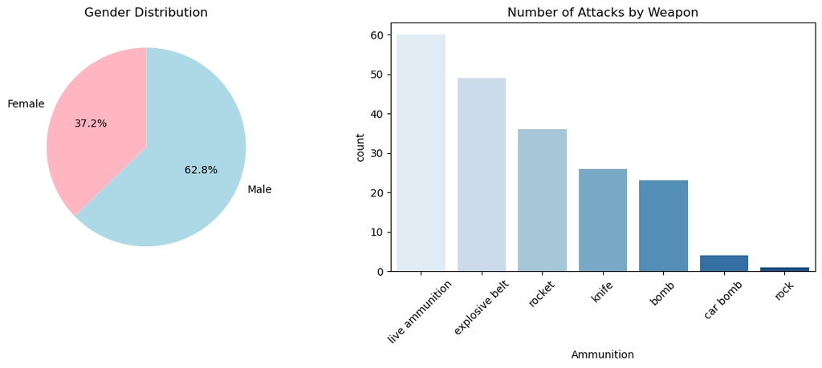

```python
fig, axes = plt.subplots(figsize=(12, 5), ncols=2)
labels = ['Female', 'Male']
sizes = [328, 553]
colors = ['lightpink', 'lightblue']
axes[0].pie(sizes, labels=labels, autopct='%1.1f%%', startangle=90, colors=colors)
axes[0].set_title('Gender Distribution')

weapon_order = grouped_incidents_full['Ammunition'].value_counts().index
sns.countplot(data=grouped_incidents_full, x='Ammunition', ax=axes[1], palette='Blues', order=weapon_order)
axes[1].set_title('Number of Attacks by Weapon')
axes[1].tick_params(axis='x', rotation=45)

plt.tight_layout()
plt.show()
```

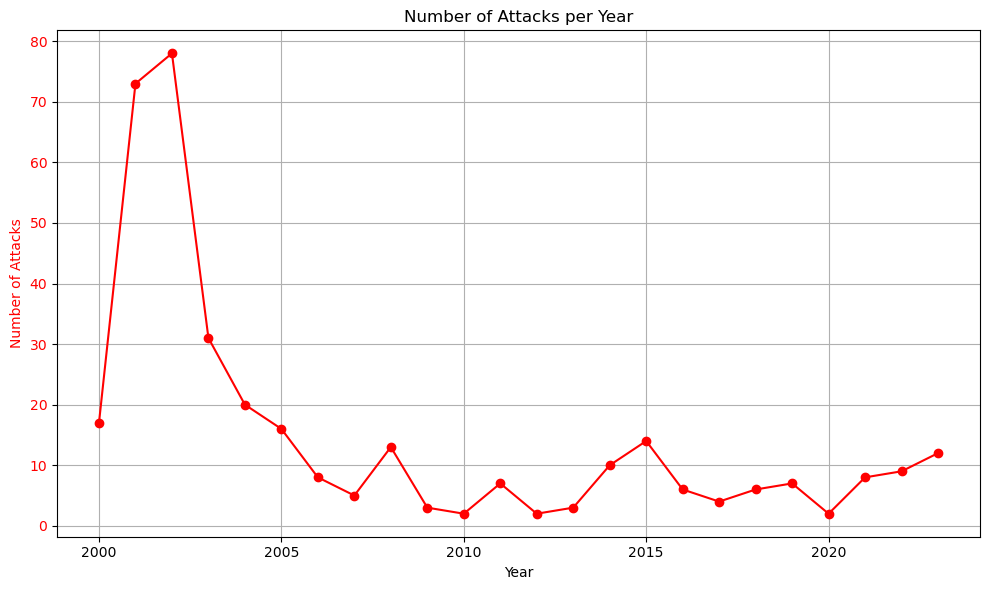

```python
grouped_incidents_full['year'] = pd.to_datetime(grouped_incidents_full['date_event']).dt.year
attacks_per_year = grouped_incidents_full.groupby('year').size()

plt.figure(figsize=(10, 6))
plt.plot(attacks_per_year.index, attacks_per_year.values, marker='o', color='red')

plt.title('Number of Attacks per Year')
plt.xlabel('Year')
plt.ylabel('Number of Attacks', color='red')
plt.tick_params(axis='y', labelcolor='red')
plt.grid(True)
plt.tight_layout()

plt.show()
```

### Correlations:

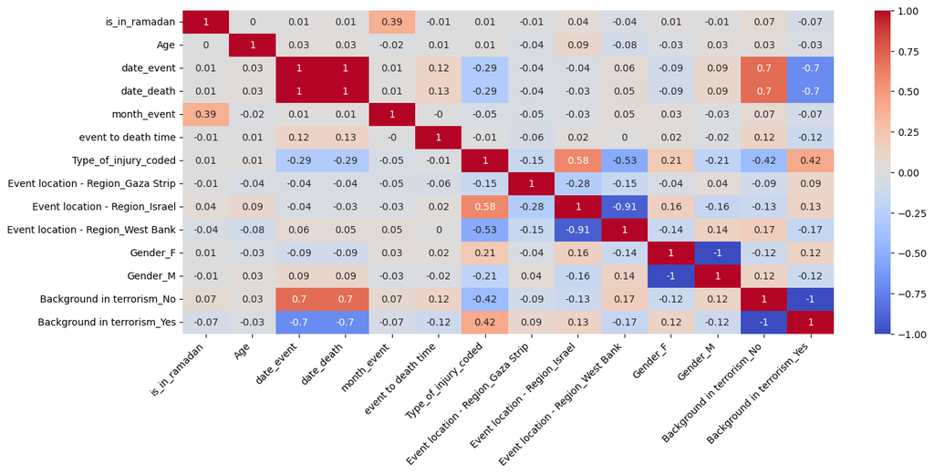

```python
numeric=['Age','date_event','date_death','month_event','event to death time','Type_of_injury_coded']
categorical=['Event location - Region','Gender','Background in terrorism','is_in_ramadan']
all_features=categorical+numeric
terror_df_num = pd.get_dummies(terror_df[all_features])
correlation_matrix=terror_df_num.corr(numeric_only=False, method='spearman').round(2)
plt.figure(figsize=(15,6))
sns.heatmap(data=correlation_matrix,cmap='coolwarm',annot=True)
plt.xticks(rotation=45, ha='right')
plt.show()
```

**Age and the Weekday effect**

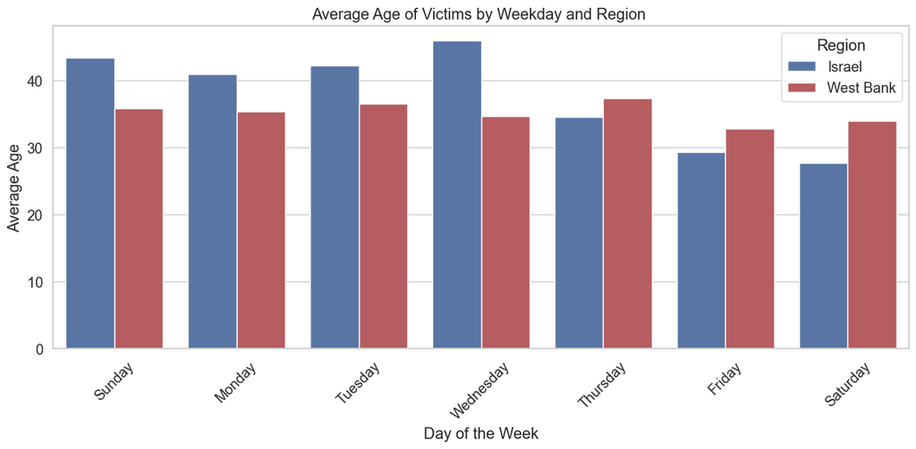

```python
weekday_order = ['Sunday', 'Monday', 'Tuesday', 'Wednesday', 'Thursday', 'Friday', 'Saturday']
terror_df['weekday_event'] = pd.Categorical(terror_df['weekday_event'], categories=weekday_order, ordered=True)

summary = terror_df.groupby(['weekday_event', 'Event location - Region']).agg({'Age': 'mean','Name': 'count'}).reset_index()
summary.columns = ['Weekday', 'Region', 'Avg Age', 'Victim Count']

summary = summary[summary['Region'] != 'Gaza Strip']

sns.set(style="whitegrid", font_scale=1.2)
plt.figure(figsize=(12, 6))

sns.barplot(data=summary, x='Weekday', y='Avg Age', hue='Region',palette = {'Israel': '#4C72B0', 'West Bank': '#C44E52' })

plt.title("Average Age of Victims by Weekday and Region ")
plt.ylabel("Average Age")
plt.xlabel("Day of the Week")
plt.xticks(rotation=45)
plt.tight_layout()
plt.show()
```

## **מסקנה ראשונה:**

**Involvement and Weapons During and Outside of Ramadan**

נבדוק את הקשר בין האם המפגע לקח חלק בפעולות איבה בעבר, לבין סוג הנשק בו בוצע הפיגוע, תוך כדי השוואה בין תקופות הרמאדן לאלו שלא.

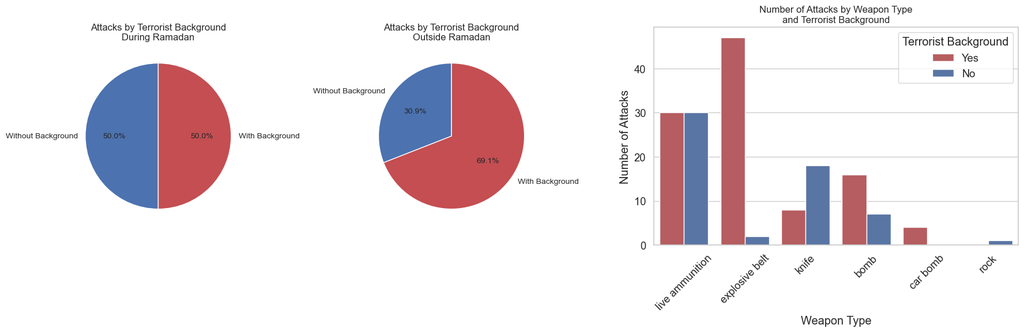

```python
summary = grouped_incidents_full.groupby(['is_in_ramadan', 'Background in terrorism']).size().unstack(fill_value=0)
labels_map = {'Yes': 'With Background', 'No': 'Without Background'}
ramadan_data = summary.loc[True].rename(index=labels_map)
non_ramadan_data = summary.loc[False].rename(index=labels_map)

df_filtered = grouped_incidents_full[grouped_incidents_full['Ammunition'] != 'rocket']

fig, (ax1, ax2, ax3) = plt.subplots(1, 3, figsize=(18, 6), gridspec_kw={'width_ratios': [1, 1, 2]})

ax1.pie(ramadan_data, labels=ramadan_data.index, autopct='%1.1f%%', startangle=90,colors=['#4C72B0', '#C44E52'], textprops={'fontsize': 10})
ax1.set_title('Attacks by Terrorist Background\nDuring Ramadan', fontsize=12)

ax2.pie(non_ramadan_data, labels=non_ramadan_data.index, autopct='%1.1f%%', startangle=90,colors=['#4C72B0', '#C44E52'], textprops={'fontsize': 10})
ax2.set_title('Attacks by Terrorist Background\nOutside Ramadan', fontsize=12)

sns.countplot(data=df_filtered,x='Ammunition',hue='Background in terrorism',palette={'Yes': '#C44E52', 'No': '#4C72B0'},order=df_filtered['Ammunition'].value_counts().index,ax=ax3)
ax3.set_title('Number of Attacks by Weapon Type\nand Terrorist Background', fontsize=12)
ax3.set_xlabel('Weapon Type')
ax3.set_ylabel('Number of Attacks')
ax3.tick_params(axis='x', rotation=45)
ax3.legend(title='Terrorist Background')

plt.tight_layout()
plt.show()
```

## **מסקנה שנייה:**

#### למפגעים שלקחו בעבר חלק בפעולות טרור יש גישה וזמינות יותר גבוהה לנשקים מתוחכמים יותר ומסוכנים יותר. אלו לא פיגועים ספונטניים של מפגע בודד, אלא התארגנות של ממש.

#### באופן מפתיע, לא צריך להיות בעל רקע בטרור כדי להשיג אקדח.

#### ניתן לראות כי בתקופות שאינן רמדאן, מרבית המפגעים הם בעלי רקע קודם בטרור, ואילו בתקופת הרמדאן ישנה עלייה במספר המפגעים החדשים – כאלה שלא השתתפו בעבר בפעילות טרור ואינם בעלי רקע קודם.

**Seasons and Their Impact**

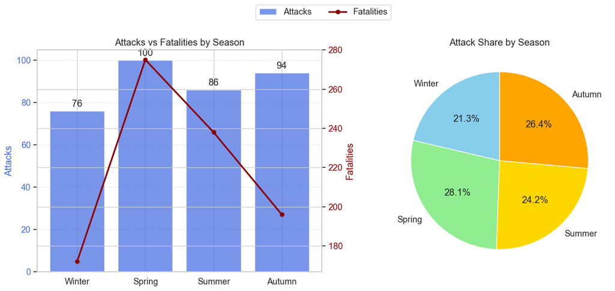

```python
seasons = ['Winter', 'Spring', 'Summer', 'Autumn']
attacks = [76, 100, 86, 94]
fatalities = [172, 275, 238, 196]
fig, (ax1, ax2) = plt.subplots(1, 2, figsize=(14, 6))

bars = ax1.bar(seasons, attacks, color='royalblue', alpha=0.7, label='Attacks')
ax1.set_ylabel('Attacks', color='royalblue')
ax1.set_title('Attacks vs Fatalities by Season')
ax1.tick_params(axis='y', labelcolor='royalblue')
ax1.grid(axis='y', linestyle='--', alpha=0.5)

# תוויות מעל כל עמודה
ax1.text(0, attacks[0] + 2, f'{attacks[0]}', ha='center')
ax1.text(1, attacks[1] + 2, f'{attacks[1]}', ha='center')
ax1.text(2, attacks[2] + 2, f'{attacks[2]}', ha='center')
ax1.text(3, attacks[3] + 2, f'{attacks[3]}', ha='center')

ax1b = ax1.twinx()
ax1b.plot(seasons, fatalities, color='darkred', marker='o', linewidth=2.5, label='Fatalities')
ax1b.set_ylabel('Fatalities', color='darkred')
ax1b.tick_params(axis='y', labelcolor='darkred')

lines1, labels1 = ax1.get_legend_handles_labels()
lines2, labels2 = ax1b.get_legend_handles_labels()
fig.legend(lines1 + lines2, labels1 + labels2, loc='upper center', ncol=2, bbox_to_anchor=(0.5, 1.05))

ax2.pie(attacks, labels=seasons, autopct='%1.1f%%', startangle=90,colors=['skyblue', 'lightgreen', 'gold', 'orange'])
ax2.set_title('Attack Share by Season')

plt.tight_layout(rect=[0, 0, 1, 0.95])
plt.show()
```

## **מסקנה שלישית:**

##### בגרף ניתן לראות שני צירי Y, צד שמאל מייצג את מספר הפיגועים וצד ימין את מספר הנרצחים.

#### מספר הפיגועים מתפלג באופן דומה בין עונות השנה, אבל ניתן לראות שבקיץ ובאביב יש את היחס פיגועים-קורבנות הגבוה ביותר. משמע, בעונות אלה הפיגועים היו קטלניים יותר וגבו קורבנות רבים באופן יחסי למספר הפיגועים.

**Region, City and Border**

[figure not shown]

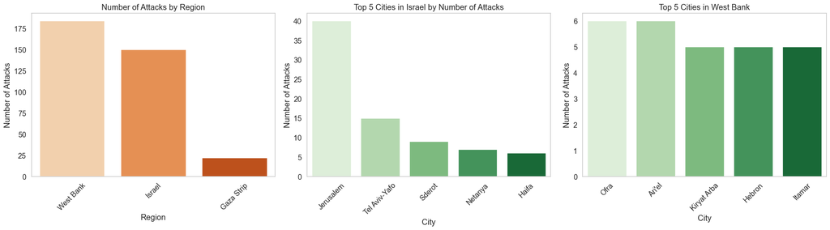

```python
top_5_israel_cities = grouped_incidents_full[grouped_incidents_full['Event location - Region'] == 'Israel']['Event location'].value_counts().head(5).index.tolist()
top_5_westbank_cities = grouped_incidents_full[(grouped_incidents_full['Event location - Region'] == 'West Bank') &(grouped_incidents_full['Event location'].str.lower() != 'jerusalem')]['Event location'].value_counts().head(5).index.tolist()

region_df = grouped_incidents_full.copy()
israel_df = region_df[region_df['Event location'].isin(top_5_israel_cities)]
westbank_df = region_df[region_df['Event location'].isin(top_5_westbank_cities)]

fig, axes = plt.subplots(1, 3, figsize=(21, 6))

# לפי אזור
sns.countplot(data=region_df, x='Event location - Region', ax=axes[0], palette='Oranges',order=region_df['Event location - Region'].value_counts().index)
axes[0].set_title('Number of Attacks by Region')
axes[0].set_xlabel('Region')
axes[0].set_ylabel('Number of Attacks')
axes[0].tick_params(axis='x', rotation=45)
axes[0].grid(axis='y')

# בישראל
sns.countplot(data=israel_df, x='Event location', ax=axes[1], palette='Greens',order=israel_df['Event location'].value_counts().index)
axes[1].set_title('Top 5 Cities in Israel by Number of Attacks')
axes[1].set_xlabel('City')
axes[1].set_ylabel('Number of Attacks')
axes[1].tick_params(axis='x', rotation=45)
axes[1].grid(axis='y')

#  בגדה (ללא ירושלים)
sns.countplot(data=westbank_df, x='Event location', ax=axes[2], palette='Greens',order=westbank_df['Event location'].value_counts().index)
axes[2].set_title('Top 5 Cities in West Bank')
axes[2].set_xlabel('City')
axes[2].set_ylabel('Number of Attacks')
axes[2].tick_params(axis='x', rotation=45)
axes[2].grid(axis='y')

plt.tight_layout()
plt.show()
```

## **מסקנה רביעית:**

#### בוצעו המון פיגועים של מפגעים פלסטינאים מעבר לגבול הקו הירוק, המפגעים היו צריכים לעבור גדר או לקבל אישור עבודה. משמע, הגדר מאוד פרוצה וקל להיכנס לשטחי המדינה.

#### בתוך גבולות הקו הירוק הפיגועים ממוקדים מאוד בערים ספציפיות, לעומת הפיגועים באזור הגדה שמתפרסים על פני ערים וישובים רבים ולא ממוקדים באף עיר או אזור.